# DATA ANALYSIS WITH PYTHON

### IMPORTS

Matplotlib is the most popular plotting package for python. Pandas is a python library used mainly for data manipulation and analysis. Pyplot is a collection of command style functions that enhance the work of matplotlib.NumPy is a python package used for scientific computing.SciPy is a python library used for scientific and technical computing. SciPy basically uses NumPy for more mathematical functions.

```python
import pandas as pd
from matplotlib import pyplot as plt
from scipy.stats import ttest_ind
import numpy as np
```

### CREATING A PANDAS DATAFRAME FROM A DATASET

```python
jersey = pd.read_csv("acs-jersey-city-economic-characteristics-2013-1.csv")
```

```python
jersey
```

|  | year | title_field | value |
| --- | --- | --- | --- |
| 0 | 2014 | Median household income | 60497.0000 |
| 1 | 2013 | Median household income | 54700.0000 |
| 2 | 2012 | Median household income | 56794.0000 |
| 3 | 2011 | Median household income | 56843.0000 |
| 4 | 2010 | Median household income | 52950.0000 |
| ... | ... | ... | ... |
| 429 | 2012 | Gini Index | 0.4969 |
| 430 | 2011 | Gini Index | 0.4686 |
| 431 | 2010 | Gini Index | 0.4770 |
| 432 | 2009 | Gini Index | 0.5090 |
| 433 | 2008 | Gini Index | 0.4870 |

434 rows × 3 columns

### Filtering Data

The current dataframe displays the variables that I plan to focus on for this project which are: Median Household Income and the Median Gross Rent.

```python
income = jersey[jersey.title_field == 'Median household income']
rent = jersey[jersey.title_field == 'Median gross rent']
```

```python
print("Income data :\n")
print(income)

print("Rent data :\n")
print(rent)
```

```
Income data :

   year              title_field    value
0  2014  Median household income  60497.0
1  2013  Median household income  54700.0
2  2012  Median household income  56794.0
3  2011  Median household income  56843.0
4  2010  Median household income  52950.0
5  2009  Median household income  57166.0
6  2008  Median household income  56079.0
Rent data :

    year        title_field   value
7   2014  Median gross rent  1189.0
8   2013  Median gross rent  1166.0
9   2012  Median gross rent  1172.0
10  2011  Median gross rent  1126.0
11  2010  Median gross rent  1123.0
12  2009  Median gross rent  1105.0
13  2008  Median gross rent  1060.0
```

### Summary Statistics

In my analysis,I assign the 'Median household income' and 'Median gross rent' variables to new variables namely: income and rent respectively.I then use the describe() function which computes a summary of statistics pertaining to the DataFrame columns to obtain the Mean, Standard deviation and Interquartile Range values of my variables.

```python
rent.describe()
```

|  | year | value |
| --- | --- | --- |
| count | 7.000000 | 7.000000 |
| mean | 2011.000000 | 1134.428571 |
| std | 2.160247 | 44.709645 |
| min | 2008.000000 | 1060.000000 |
| 25% | 2009.500000 | 1114.000000 |
| 50% | 2011.000000 | 1126.000000 |
| 75% | 2012.500000 | 1169.000000 |
| max | 2014.000000 | 1189.000000 |

```python
income.describe()
```

|  | year | value |
| --- | --- | --- |
| count | 7.000000 | 7.000000 |
| mean | 2011.000000 | 56432.714286 |
| std | 2.160247 | 2331.369391 |
| min | 2008.000000 | 52950.000000 |
| 25% | 2009.500000 | 55389.500000 |
| 50% | 2011.000000 | 56794.000000 |
| 75% | 2012.500000 | 57004.500000 |
| max | 2014.000000 | 60497.000000 |

### Data Visualization

**Line Graph**

Data Visualization is usually the first step of any work involving data analysis. Creating visualizations really helps in making things clearer and easier to understand.Line charts are best used when you can clearly see that one variable varies greatly with another i.e they have a high covariance. In the first graph, the year associated with the income is plotted on the x-axis while the values associated with the varibale income are plotted on the y-axis while in the second graph,the year associated with the rent is plotted on the x-axis while the values associated with the rent varibale income are plotted on the y-axis

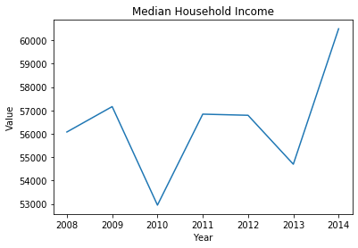

```python
plt.plot (income.year, income.value)
plt.title ("Median Household Income")
plt.xlabel("Year")
plt.ylabel("Value")
plt.show()
```

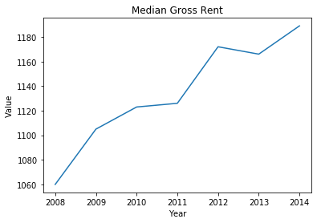

```python
plt.plot (rent.year, rent.value)
plt.title ("Median Gross Rent")
plt.xlabel("Year")
plt.ylabel("Value")
plt.show()
```

### Plotting on same axes

I was further interested in plotting both the variables income and rent on the same chart.The values associated with the variable income were very high compared to the values associated with the rent variable so I divided the income values by 50 to have a more presentable visualization.

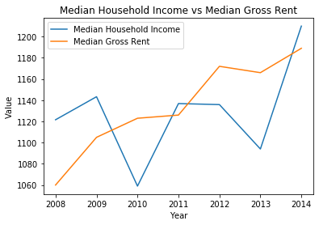

```python
plt.plot (income.year, income.value/50)
plt.plot (rent.year, rent.value)
plt.title ("Median Household Income vs Median Gross Rent")
plt.xlabel("Year")
plt.ylabel("Value")
plt.legend(["Median Household Income","Median Gross Rent"])
plt.show()
```

### Bar Graph

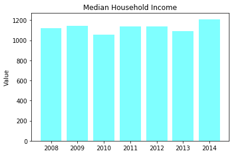

```python
plt.bar (income.year, income.value/50,align='center',alpha=0.5, color=['cyan'])
plt.xticks(income.year)
plt.ylabel('Value')
plt.title('Median Household Income')

plt.show()
```

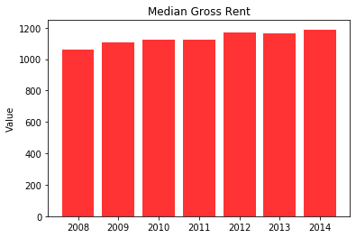

```python
plt.bar(income.year, rent.value, alpha=0.8,color=['red'])
plt.xticks(rent.year)
plt.ylabel('Value')
plt.title('Median Gross Rent')

plt.show()
```

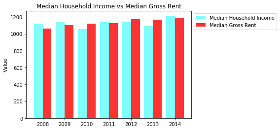

```python
plt.bar (income.year, income.value/50, -0.4 , align='edge',alpha=0.5,color=['cyan'])
plt.bar (income.year, rent.value, 0.4 , align='edge', alpha=0.8,color=['red'])
plt.xticks(income.year)
plt.xticks(rent.year)
plt.ylabel('Value')
plt.title('Median Household Income vs Median Gross Rent')
plt.legend(["Median Household Income","Median Gross Rent"], bbox_to_anchor=(1.0, 1.0))


plt.show()
```

### Measuring Statistics

I compute the mean and standard values of the income and rent variable by calling numpy and print the results

```python
income_mean = np.mean(income)
rent_mean = np.mean(rent)

print("income mean value:\n",income_mean)
print("rent mean value:\n",rent_mean)
```

```
income mean value:
 year      2011.000000
value    56432.714286
dtype: float64
rent mean value:
 year     2011.000000
value    1134.428571
dtype: float64
```

```python
income_std = np.std(income)
rent_std = np.std(rent)

print("income standard value:\n",income_std)
print("rent standard value:\n",rent_std)
```

```
income standard value:
 year        2.000000
value    2158.428642
dtype: float64
rent standard value:
 year      2.000000
value    41.393088
dtype: float64
```

### Hypothesis Testing

Using the Scipy library, I carry out a statistics test to find out if the data between the Median Household Income and the Median Household Rent is significant. I use a T-Test of Independece which is the test used for the means of two independent samples. The null hypothesis in my study is that the Median Household Income and the Median Household Rent have identical average values and I'm hoping to either reject or accept it based off the results of my p-value.A p-value helps you determine the significance of your results when you perform a hypothesis test.If we reject the null hypothesis, the results are considered significant.

```python
ttest,pval = ttest_ind(income['value'], rent['value'])
print("The p-value is",pval)

if pval < 0.05:
  print("We reject the null hypothesis")
else:
  print("We accept the null hypothesis")
```

```
The p-value is 1.779090659893951e-16
We reject the null hypothesis
```